# Introdução aos Modelos Bayesianos Generalizados

Joseferson da Silva Barreto

2022-10-12

**Professor(a):** Fenanda Clotilde

Projeto final Inferência Bayesiana apresentado na última aula da disciplina.

# Objetivo

O objetivo é apresentar de forma clara oque são os modelos lineares bayesianos , e verificar sua importância para análises estatísticas.

# Método

Foi feito os tratamentos dos dados para buscar relações entre as variáveis , a limpeza dos dados foi feita no software Rstudio ,utilizando a linguagem R para as demais análises. Para essa análise foi utilizado um banco de dados sobre os prejuízos causados as seguradoras pelos furacões nos Estados Únidos de 1954 a 1984.

# Introdução

Os modelos Bayesianos são utilizados quando estamos buscando explicar o desconhecido atrávez de distribuições de probabilidades de modo subjetivo ,ou seja, a inferência Bayesiana é uma metodologia estatística baseada na definição de probabilidade como um grau de informação. Neste artigo veremos um modelo de poisson bayesiano generalizado.

Matematicamente o modelo Linear Generralizado de poisson é aplicado quando temos a ocorrência de eventos discretos ao longo de intervalos especificos, entrentanto, para utilizar os modelos de poisson é necessário verificar se não tem excesso de zeros e se nossos dados não estão tão dispersos, além disso nossos dados tem que ser discretos .

- sem exceso de zeros e com dispersão: poisson com dispersão e binomial negativa sem/com dispersão

Os dados utilizados nesse artigo é de uma pesquisa feita em 2014 sobre os prejuízos causados as seguradoras pelos furacões que ocorre regularmente nos estados únidos, esse dataset é de 1954 a 1984.

# Carregando o Banco de Dados

Para carregar nosso conjunto de dados vamos utilizar os comandos a baixo, nosso dataset utilizado nesse arquivo está disponível no guithub

```r
library (readr)
urlfile="https://raw.githubusercontent.com/metodosexatos/mlgbayes/main/DatasetsES15/hurricanes.csv"
mydata<-read_csv2(url(urlfile)) # para csv no formato brasileiro use read_csv2#head(mydata)
```

## Verificando os Histograma da Priori

A distribuição a priori de Poisson é definida de forma caso uma variável aleatória discreta $Y$ tem uma distribuição de Poisson com parâmetro $\theta > 0$ se sua função de massa de probabilidade satisfaz:

$$f(y|\theta): \frac{e^{-\theta}
\theta^{y}}{y!}, \quad y= 0,1,2 ...$$
Se $Y$ tem um Poisson($\theta$) distribuição então

$E(y)=\theta$  
$Var(y)=\theta$

Vamos observar a nossa distribuição apriori atravéz do histograma gerado com o código abaixo:

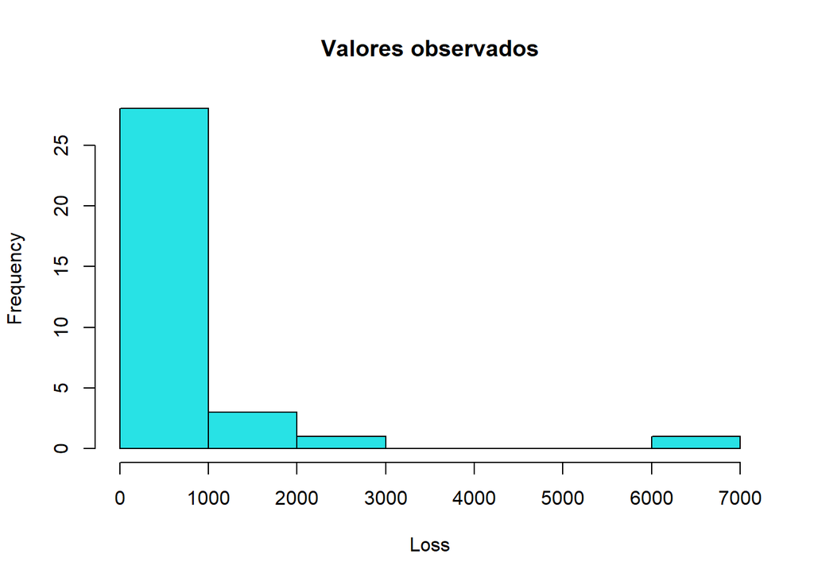

```r
#------------
# Histograma da vari?vel dependente:

k <- round(1+3.3*log10(nrow(mydata)),0) # N?mero de classes: Regra de Sturges
hist(mydata$loss, main = "Valores observados", xlab = "Loss", nclass = k, col = 5)
```

```r
mean(mydata$loss)
```

```
## [1] 563.4545
```

Como temos poucas observações nós não conseguimos observar muito bem se ele segue a distribuição de poisson, sabemos que só temos informação sobre o conjuto dos naturais